# COVID-19 case report graphing exercise

Peter van Heusden pvh@sanbi.ac.za

08 March 2020

## COVID-19 cases graphed, in R and Python

I do my day to day programming in Python, not R, so as an exercise in strengthening my R skills I decided to do some graphing of COVID-19 case numbers. Google helped me (of course) as did the [R for Data Science](https://r4ds.had.co.nz/) book and a plethora of other pages. The data that I used was from Johns Hopkins University CSSE Github [repository](https://github.com/CSSEGISandData), I just made a [tinyurl](http://j.mp/covid19casescsvnew) to make it simpler to type in the code.

First, the R libraries used:

```r
library(tidyverse)
library(lubridate)
```

```r
data_source <- 'http://j.mp/covid19casescsvnew'
covid19 <- read_csv(url(data_source)) %>%
  rename(Country = "Country/Region") %>%
  select(-c("Province/State", "Lat", "Long")) %>%
  pivot_longer(-Country, names_to = "textdate", values_to = "Cases") %>%
  mutate(Date = mdy(textdate)) %>%
  arrange(Date) %>%
  select(-textdate)
```

It extensively uses “tidyverse” modules and the associated concept of pipes. I.e. the data is retrieved and then read in as a [tibble](https://r4ds.had.co.nz/tibbles.html) then columns I don’t need are dropped, the data is converted from [wide to long form](https://www.theanalysisfactor.com/wide-and-long-data/), date values are converted from text to date types and the tibble is sorted by date.

Here is the equivalent Python. First the libraries used:

```python
import pandas as pd
import io
import requests
import altair as alt
```

and then the associated Python code for getting the data

```python
# fetch data using requests
url = "http://j.mp/covid19casescsvnew"
content_string = requests.get(url).content
raw_data = pd.read_csv(io.StringIO(content_string.decode('utf-8')))

value_columns = raw_data.columns[4:]
covid19 = raw_data.drop(
    ['Province/State', 'Lat', 'Long'], axis=1).melt(
        id_vars=['Country/Region'], value_vars=value_columns, var_name='textdate', value_name='Cases')
covid19['Date'] = covid19['textdate'].apply(pd.to_datetime)
covid19 = covid19.sort_values(by=['Date']).drop(['textdate'], axis=1)
covid19.columns = ['Country', 'Cases', 'Date']
```

The Python code uses [requests](https://requests.readthedocs.io/en/master/) to get data and then [Pandas](https://pandas.pydata.org/) to manipulate it. It does not have special purpose syntax like the `%>%` pipe or `%in%` (seen below) but otherwise it has similar features, e.g. `drop` is like `select` and `melt` is like `pivot_long`. It also spreads across a few statements, as opposed to the R single long chain of operations. Wesley Goi has a great post on the equivalences between [Python and tidyverse R](https://towardsdatascience.com/tidying-up-pandas-4572bfa38776).

And now for the graphs. First in R with ggplot:

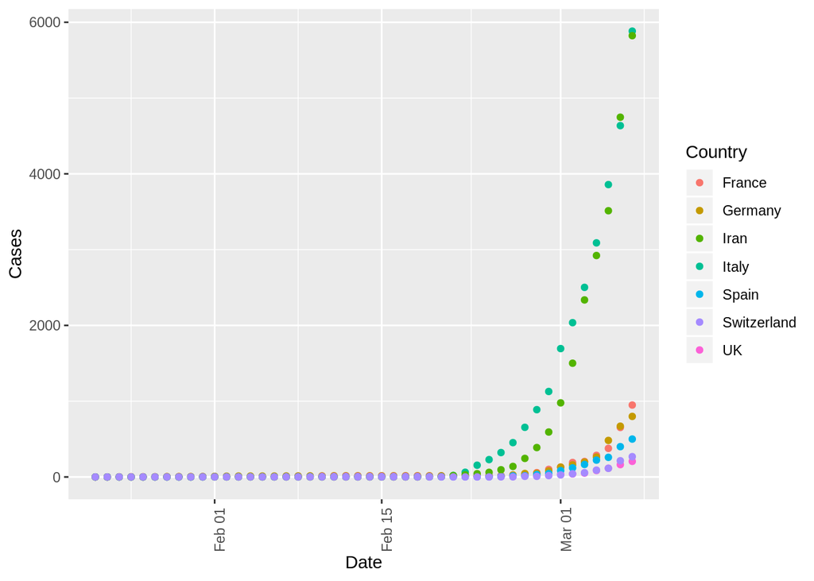

```r
covid19 %>%
  filter(Country %in% c("Iran",
                        "Italy",
                        "Switzerland",
                        "France",
                        "Spain",
                        "Germany",
                        "UK")) %>%
  ggplot(aes(x=Date, y=Cases, col=Country)) + geom_point() + theme(axis.text.x = element_text(angle = 90))
```

```python
chart = alt.Chart(covid19[covid19.Country.isin(['Iran',
                                        'Italy',
                                       'France',
                                       'Spain',
                                       'Germany',
                                       'UK'])],
                 width=600
                 ).mark_point().encode(x=alt.X('monthdate(Date)',
                                                  axis=alt.Axis(labelAngle=90)),
                                         y='Cases', color='Country').to_json()
```

```r
library(vegawidget)

as_vegaspec(py$chart)
```

[interactive chart not shown]

Again the Python style of functions is used, and it makes neat formatting quite difficult to achieve. Formatting is expressed as chained functions or options within those functions, which has the advantage of consistency (there is no need to learn new syntax).

To display in RMarkdown I used the tips from [https://github.com/altair-viz/altair/issues/1940], i.e. output a chart as JSON (using `.to_json()` on the Altair Chart object) and the use the R `as_vegaspec` function from the [vegawidget](https://rdrr.io/cran/vegawidget/) library to display the chart.

### Aggregating by country

While Italy and UK are being treated “as a whole” in this data, some countries (like USA) are being dealt with state by state. This means data needs to be aggregated. This Python does that:

```python
value_columns = raw_data.columns[4:]
covid19 = raw_data.drop(
    ['Lat', 'Long'], axis=1).melt(
        id_vars=['Country/Region', 'Province/State'], value_vars=value_columns, var_name='textdate', value_name='Cases')
covid19['Date'] = covid19['textdate'].apply(pd.to_datetime)
covid19 = covid19.sort_values(by=['Date']).drop(['textdate'], axis=1)
covid19.columns = ['Country', 'Province/State', 'Cases', 'Date']
grouped = covid19.groupby(['Date', 'Country'], as_index=False).sum()
```

and then it can be plotted:

```python
chart2 = alt.Chart(grouped[grouped.Country.isin(['US', 'Italy'])]).mark_point().encode(x=alt.X('monthdate(Date)',
                                                  axis=alt.Axis(labelAngle=90)),
                                         y='Cases', color='Country')
chart2_json = chart2.to_json()
chart2
```

```
## alt.Chart(...)
```

```r
as_vegaspec(py$chart2_json)
```

[interactive chart not shown]

The equivalent in R (including plotting) is this:

```r
data_source <- 'http://j.mp/covid19casescsvnew'
covid19 <- read_csv(url(data_source)) %>%
  rename(Country = "Country/Region") %>%
  rename(State = "Province/State") %>%
  select(-c("Lat", "Long")) %>%
  pivot_longer(-c(Country, State), names_to = "textdate", values_to = "Cases") %>%
  mutate(Date = mdy(textdate)) %>%
  arrange(Date) %>%
  select(-textdate) %>%
  group_by(Country, Date) %>%
  summarise(Cases = sum(Cases))
```

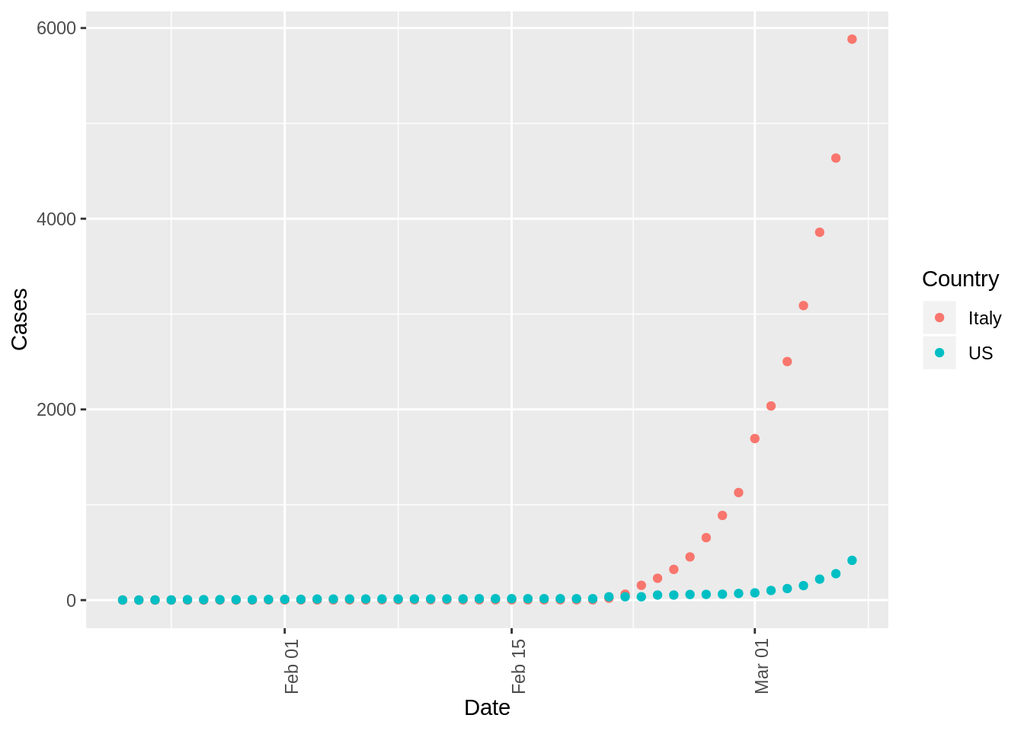

```r
covid19 %>%
  filter(Country %in% c("US", "Italy")) %>%
  ggplot(aes(x=Date, y=Cases, col=Country)) + geom_point() + theme(axis.text.x = element_text(angle = 90))
```